# R Markdown Report for analysis of developing gut microbiome in infants en route to type 1 diabetes (TID)

Raymond Atuhe, Reg No: 2020/HDO7/22160U, Student Number: 2000722160

25 06 2021

# Background

This is an R markdown script explaining and running analysis of developing gut microbiome in infants en route to type 1 diabetes (TID). The data is based on two Bioconductor packages; phyloseq and DEseq2. It was given as an assignemnt in completion of a masters Degree in Bioinformatics.

## Load necessary libraries

```r
library("phyloseq")
library("ggplot2")      # graphics
library("readxl")       # necessary to import the data from Excel file
library("dplyr")        # filter and reformat data frames
library("tibble")       # Needed for converting column to row names
library("readr")        #read Rectangular Text data
library("DESeq2")       #Needed to normalize, visualize, and differential analysis if high dimensional data
library("table1")       #Tables of Descriptive statistics
library("tidyverse")
```

## 1. Importing the data described below into R and providing Descriptive statistics

All data files should be in the same working folder for easy analysis.  
I was given 2 data files; i.e. * diabimmune_16s_t1d_metadata.csv * diabimmune_t1d_16s_otu_table.txt

The second data file was given as a text delimited file(.txt), and contained both the Taxonomic Units and Abundances.

For better analysis i had to separate diabimmune_t1d_16s_otu_table.txt to get OTUs and Taxonomy’s from the Terminal.

The .csv file was read into R by importing it directly as below.

```r
#Importing sample data into R.
metadata <- read.csv("diabimmune_16s_t1d_metadata.csv")
head(metadata)
```

```
##   Sample_ID Subject_ID Case_Control Gender Delivery_Route Age_at_Collection
## 1    G36449    E001463      control   male        vaginal                62
## 2    G36034    E001463      control   male        vaginal                82
## 3    G36993    E001463      control   male        vaginal               124
## 4    G35523    E001463      control   male        vaginal               153
## 5    G36450    E001463      control   male        vaginal               187
## 6    G36028    E001463      control   male        vaginal               213
```

#### Providing descriptive summaries of the subject data (using appropriate graphics and statistical summary measures) given in the diabimmune_16s_t1d_metadata.csv file.

- Running a few summary statistics on the sample data file such as structure, summary etc .

```r
#Run summary statistics of the metadata file.
summary(metadata)
```

```
##    Sample_ID     Subject_ID   Case_Control    Gender     Delivery_Route
##  G35348 :  1   E018113: 34   case   :260   female:412   cesarian: 66
##  G35349 :  1   E022137: 34   control:517   male  :365   vaginal :711
##  G35350 :  1   E001463: 32
##  G35351 :  1   E006574: 32
##  G35352 :  1   E011279: 32
##  G35354 :  1   E017751: 32
##  (Other):771   (Other):581
##  Age_at_Collection
##  Min.   :   6.0
##  1st Qu.: 229.0
##  Median : 452.0
##  Mean   : 482.9
##  3rd Qu.: 702.0
##  Max.   :1233.0
##
```

```r
#Identify the structure of the data.
str(metadata)
```

```
## 'data.frame':    777 obs. of  6 variables:
##  $ Sample_ID        : Factor w/ 777 levels "G35348","G35349",..: 461 224 728 93 462 218 219 94 463 44 ...
##  $ Subject_ID       : Factor w/ 33 levels "E001463","E003061",..: 1 1 1 1 1 1 1 1 1 1 ...
##  $ Case_Control     : Factor w/ 2 levels "case","control": 2 2 2 2 2 2 2 2 2 2 ...
##  $ Gender           : Factor w/ 2 levels "female","male": 2 2 2 2 2 2 2 2 2 2 ...
##  $ Delivery_Route   : Factor w/ 2 levels "cesarian","vaginal": 2 2 2 2 2 2 2 2 2 2 ...
##  $ Age_at_Collection: int  62 82 124 153 187 213 243 276 303 366 ...
```

Running a descriptive summaries of the subject data with graphics like boxplots, ggplots etc. * Count of the number of observations in the data [Case control vs Gender]

```r
#Descriptive Statistics
#Count of the number of observations in the data
#Case control vs Gender
Gender_Count <- table(metadata$Case_Control, metadata$Gender)
total.p <- prop.table(Gender_Count)
row.p <- prop.table(Gender_Count,1)
column.p <- prop.table(Gender_Count,2)
list(Count=Gender_Count,"Total Percentage"=round(total.p,3),"Row Percentage"=round(row.p,3),"Column
Percentage"=round(column.p,3))
```

```
## $Count
##
##           female male
##   case       142  118
##   control    270  247
##
## $`Total Percentage`
##
##           female  male
##   case     0.183 0.152
##   control  0.347 0.318
##
## $`Row Percentage`
##
##           female  male
##   case     0.546 0.454
##   control  0.522 0.478
##
## $`Column\nPercentage`
##
##           female  male
##   case     0.345 0.323
##   control  0.655 0.677
```

#### Count of the number of observations in the data [Gender vs Delivery Route]

Gender vs Delivery Route

```r
Delivery_Count <- table(metadata$Gender, metadata$Delivery_Route)
total.p <- prop.table(Delivery_Count)
row.p <- prop.table(Delivery_Count,1)
column.p <- prop.table(Delivery_Count,2)
list(Count=Delivery_Count,"Total Percentage"=round(total.p,3),"Row Percentage"=round(row.p,3),"Column
Percentage"=round(column.p,3))
```

```
## $Count
##
##          cesarian vaginal
##   female       38     374
##   male         28     337
##
## $`Total Percentage`
##
##          cesarian vaginal
##   female    0.049   0.481
##   male      0.036   0.434
##
## $`Row Percentage`
##
##          cesarian vaginal
##   female    0.092   0.908
##   male      0.077   0.923
##
## $`Column\nPercentage`
##
##          cesarian vaginal
##   female    0.576   0.526
##   male      0.424   0.474
```

#### Table1

- Table that presents descriptive statistics of baseline characteristics of the subject data.

```r
table1(~ Gender + Age_at_Collection + Case_Control | Delivery_Route, data=metadata, topclass="Rtable1-zebra")
```

|  | cesarian (N=66) | vaginal (N=711) | Overall (N=777) |
| --- | --- | --- | --- |
| Gender |  |  |  |
| female | 38.0 (57.6%) | 374 (52.6%) | 412 (53.0%) |
| male | 28.0 (42.4%) | 337 (47.4%) | 365 (47.0%) |
| Age_at_Collection |  |  |  |
| Mean (SD) | 463 (299) | 485 (294) | 483 (295) |
| Median [Min, Max] | 393 [51.0, 1090] | 457 [6.00, 1230] | 452 [6.00, 1230] |
| Case_Control |  |  |  |
| case | 0 (0%) | 260 (36.6%) | 260 (33.5%) |
| control | 66.0 (100%) | 451 (63.4%) | 517 (66.5%) |

#### Appropriate Graphics on the subject data

- Defining objects to use in visualizations.

```r
Gender <- metadata$Gender
Age_at_Collection <- metadata$Age_at_Collection
Delivery_Route <- metadata$Delivery_Route
Case_Control <- as.factor(metadata$Case_Control)
plot_colours <- ifelse(levels(Case_Control)=="case", rgb(0.1,0.1,0.7,0.5),
                   ifelse(levels(Case_Control)=="control", "red", rgb(0.8,0.1,0.3,0.6) ))
```

#### Boxplot

Basic Boxplot of Disease Status vs Age

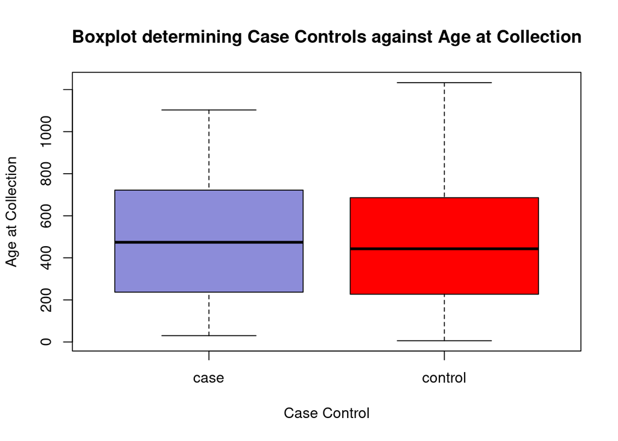

```r
boxplot(Age_at_Collection~ Case_Control, main="Boxplot determining Case Controls against Age at Collection", xlab="Case Control", ylab="Age at Collection", col=plot_colours)
```

#### Bar Graph. Basic Bar graph repesenting precenatges of Gender by Delivery Route

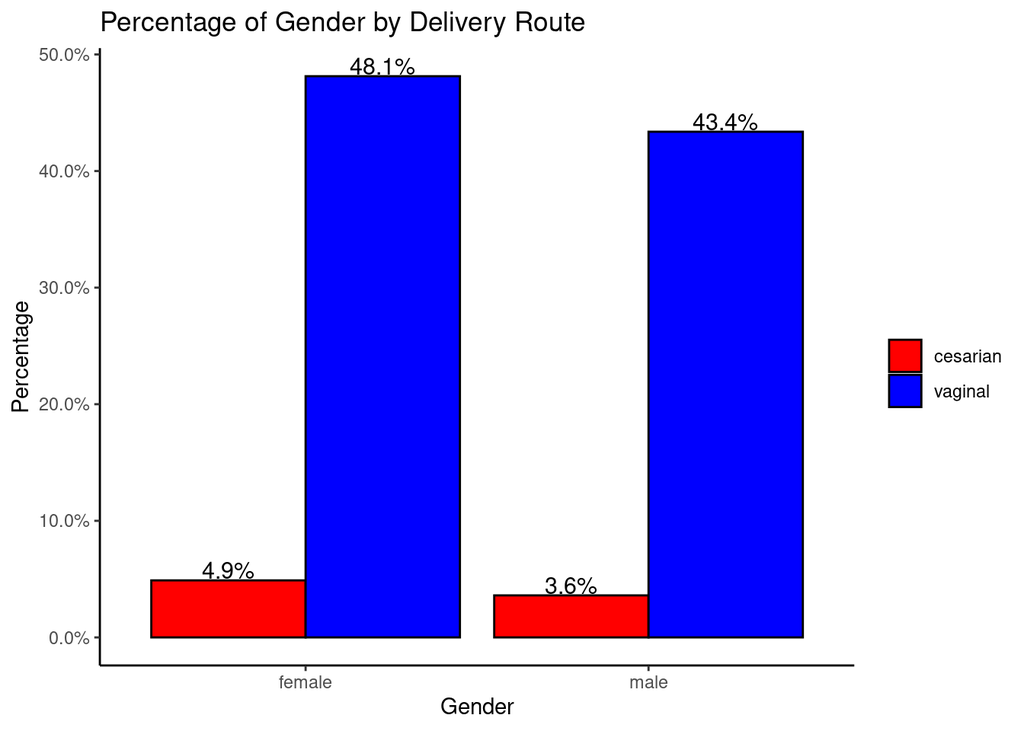

```r
#ggplot graphs
ggplot(metadata, aes(x = Gender ,y= (..count..)/sum(..count..), fill= Delivery_Route)) +
  geom_bar(position = "dodge", color= "Black")+
  scale_y_continuous(labels=scales::percent)+
  labs(title = "Percentage of Gender by Delivery Route", y= "Percentage", x= "Gender" )+
  geom_text(stat= "count", aes(label= scales::percent((..count..)/sum(..count..))), position = position_dodge(0.9), size=4, vjust=-0.1)+
  theme_classic()+ scale_fill_manual(name = "", values = c("red", "blue"))
```

#### Association Tests between Case Control and Gender

Fisher’s Exact Test for Count Data

```r
fisher.test(Case_Control, Gender)
```

```
##
##  Fisher's Exact Test for Count Data
##
## data:  Case_Control and Gender
## p-value = 0.543
## alternative hypothesis: true odds ratio is not equal to 1
## 95 percent confidence interval:
##  0.8074825 1.5018846
## sample estimates:
## odds ratio
##   1.100742
```

## Chi Square

Testing relationships between categorical variables

```r
chisq.test(Case_Control, Gender)
```

```
##
##  Pearson's Chi-squared test with Yates' continuity correction
##
## data:  Case_Control and Gender
## X-squared = 0.30687, df = 1, p-value = 0.5796
```

```r
chisq.test(Case_Control, Delivery_Route)
```

```
##
##  Pearson's Chi-squared test with Yates' continuity correction
##
## data:  Case_Control and Delivery_Route
## X-squared = 34.649, df = 1, p-value = 3.949e-09
```

#### Association Tests between Delivery Route and Gender

Fisher’s Exact Test for Count Data of Delivery Route and Gender

```r
fisher.test(Delivery_Route, Gender)
```

```
##
##  Fisher's Exact Test for Count Data
##
## data:  Delivery_Route and Gender
## p-value = 0.5195
## alternative hypothesis: true odds ratio is not equal to 1
## 95 percent confidence interval:
##  0.7133402 2.1170536
## sample estimates:
## odds ratio
##   1.222564
```

#### Association Tests between Delivery Route and Case_Control

Fisher’s Exact Test for Count Data of Delivery Route and Case_Control

```r
fisher.test(Delivery_Route, Case_Control)
```

```
##
##  Fisher's Exact Test for Count Data
##
## data:  Delivery_Route and Case_Control
## p-value = 6.86e-13
## alternative hypothesis: true odds ratio is not equal to 1
## 95 percent confidence interval:
##  0.0000000 0.1010148
## sample estimates:
## odds ratio
##          0
```

#### T-Test

A test to determine whether the means of two groups are equal to each other. * Below is a t-test of Age_at_Collection by Case_Control

```r
t.test(Age_at_Collection~Case_Control)
```

```
##
##  Welch Two Sample t-test
##
## data:  Age_at_Collection by Case_Control
## t = 1.0195, df = 502.81, p-value = 0.3085
## alternative hypothesis: true difference in means is not equal to 0
## 95 percent confidence interval:
##  -21.43301  67.66969
## sample estimates:
##    mean in group case mean in group control
##              498.2731              475.1547
```

```r
t.test(Age_at_Collection~Gender)
```

```
##
##  Welch Two Sample t-test
##
## data:  Age_at_Collection by Gender
## t = -2.0766, df = 750.95, p-value = 0.03818
## alternative hypothesis: true difference in means is not equal to 0
## 95 percent confidence interval:
##  -85.698440  -2.406986
## sample estimates:
## mean in group female   mean in group male
##             462.1966             506.2493
```

#### Models

```r
model = glm(Case_Control ~ Gender + Delivery_Route + Age_at_Collection, family = binomial)
summary(model)
```

```
##
## Call:
## glm(formula = Case_Control ~ Gender + Delivery_Route + Age_at_Collection,
##     family = binomial)
##
## Deviance Residuals:
##     Min       1Q   Median       3Q      Max
## -1.5032  -1.3854   0.9051   0.9596   1.0564
##
## Coefficients:
##                         Estimate Std. Error z value Pr(>|z|)
## (Intercept)            1.763e+01  4.862e+02   0.036    0.971
## Gendermale             1.375e-01  1.566e-01   0.878    0.380
## Delivery_Routevaginal -1.702e+01  4.862e+02  -0.035    0.972
## Age_at_Collection     -2.614e-04  2.648e-04  -0.987    0.324
##
## (Dispersion parameter for binomial family taken to be 1)
##
##     Null deviance: 990.52  on 776  degrees of freedom
## Residual deviance: 932.07  on 773  degrees of freedom
## AIC: 940.07
##
## Number of Fisher Scoring iterations: 16
```

#### 2. creating a phyloseq object. This comprises of the OTU abundance, taxonomy and sample data (provided in the .csv file).

To create a phyloseq object, I Imported data into R. * All files are in my working directory to where the they are located * Three tables are required * OTU abundance * Taxonomy * sample data

```r
# Importing OTU abundance table
OTU_Table <- read.table("otu_table")

# Importing Taxonomy table
Taxa_Table <- read.table("new_taxa_table")
```

View the contents and class of the data stored in objects above.

```r
head(OTU_Table)
```

```
##         G37016 G36918 G37044 G37009 G37029 G37035 G36982 G36984 G37030 G37031
## 4333897     12      1     12      0      0     22      0      0      0     35
## 190162       2      1      0      1      4      0     15     20      3      0
## 134726      13    127      0      0      0      0      0      0      0      0
## 679245      10      4      0      0      0     15      0      9      0      0
## 289734     313    923    101    701    545      0   2786   3756    440     10
## 302049      11     40      4     22     20      0    101    190     25      0
##         G36906 G37028 G37014 G37010 G36944 G36902 G37051 G36964 G36951 G37025
## 4333897      1     27     36      4      1      0      3     24      0      0
## 190162      48      0      4      5      1     14      0      0      4      3
## 134726       1      0      0     42      0      0    502      0      0     26
## 679245       0      7      3      0      0      0     28      0      0      0
## 289734    2954      0   1037   1555   1666   1033      0    103   1485    633
## 302049     100      0     39    127     62     46      0      0     72     20
##         G36930 G36935 G37041 G36959 G36905 G36917 G36992 G36921 G37004 G36966
```

[output cut: 531 more lines]

```r
head(Taxa_Table)
```

```
##               Domain.            Phylum.                  Class.
## 4333897; k__Bacteria; p__Proteobacteria; c__Gammaproteobacteria;
## 190162;  k__Bacteria;     p__Firmicutes;          c__Clostridia;
## 134726;  k__Bacteria;     p__Firmicutes;             c__Bacilli;
## 679245;  k__Bacteria;     p__Firmicutes;             c__Bacilli;
## 289734;  k__Bacteria;     p__Firmicutes;          c__Clostridia;
## 302049;  k__Bacteria;     p__Firmicutes;          c__Clostridia;
##                         Order.                Family.            Genus. Species
## 4333897; o__Enterobacteriales; f__Enterobacteriaceae;              g__;     s__
## 190162;      o__Clostridiales;    f__Lachnospiraceae;       g__Blautia;     s__
## 134726;    o__Lactobacillales;   f__Lactobacillaceae; g__Lactobacillus;     s__
## 679245;    o__Lactobacillales;   f__Lactobacillaceae; g__Lactobacillus;     s__
## 289734;      o__Clostridiales;    f__Lachnospiraceae;              g__;     s__
## 302049;      o__Clostridiales;    f__Lachnospiraceae;       g__Blautia;     s__
```

```r
dim(OTU_Table)
```

```
## [1] 2240  777
```

```r
dim(Taxa_Table)
```

```
## [1] 2240    7
```

```r
class(OTU_Table)
```

```
## [1] "data.frame"
```

```r
class(Taxa_Table)
```

```
## [1] "data.frame"
```

Transform into matrixes otu and tax tables

```r
# convert the otu table into a matrix
OTU_mat <- as.matrix(OTU_Table)
class(OTU_mat)
```

```
## [1] "matrix"
```

```r
# convert the taxonomy table into a matrix
Taxa_mat <- as.matrix(Taxa_Table)
class(Taxa_mat)
```

```
## [1] "matrix"
```

```r
head(Taxa_mat)
```

```
##          Domain.        Phylum.              Class.
## 4333897; "k__Bacteria;" "p__Proteobacteria;" "c__Gammaproteobacteria;"
## 190162;  "k__Bacteria;" "p__Firmicutes;"     "c__Clostridia;"
## 134726;  "k__Bacteria;" "p__Firmicutes;"     "c__Bacilli;"
## 679245;  "k__Bacteria;" "p__Firmicutes;"     "c__Bacilli;"
## 289734;  "k__Bacteria;" "p__Firmicutes;"     "c__Clostridia;"
## 302049;  "k__Bacteria;" "p__Firmicutes;"     "c__Clostridia;"
##          Order.                  Family.                  Genus.
## 4333897; "o__Enterobacteriales;" "f__Enterobacteriaceae;" "g__;"
## 190162;  "o__Clostridiales;"     "f__Lachnospiraceae;"    "g__Blautia;"
## 134726;  "o__Lactobacillales;"   "f__Lactobacillaceae;"   "g__Lactobacillus;"
## 679245;  "o__Lactobacillales;"   "f__Lactobacillaceae;"   "g__Lactobacillus;"
## 289734;  "o__Clostridiales;"     "f__Lachnospiraceae;"    "g__;"
## 302049;  "o__Clostridiales;"     "f__Lachnospiraceae;"    "g__Blautia;"
##          Species
## 4333897; "s__"
## 190162;  "s__"
## 134726;  "s__"
## 679245;  "s__"
## 289734;  "s__"
## 302049;  "s__"
```

Removing ; from the columns of Taxa_Table

```r
# remove ; from the columns of taxonomy table
Taxa_mat_sub <- gsub(";", "", Taxa_mat)
head(Taxa_mat_sub)
```

```
##          Domain.       Phylum.             Class.
## 4333897; "k__Bacteria" "p__Proteobacteria" "c__Gammaproteobacteria"
## 190162;  "k__Bacteria" "p__Firmicutes"     "c__Clostridia"
## 134726;  "k__Bacteria" "p__Firmicutes"     "c__Bacilli"
## 679245;  "k__Bacteria" "p__Firmicutes"     "c__Bacilli"
## 289734;  "k__Bacteria" "p__Firmicutes"     "c__Clostridia"
## 302049;  "k__Bacteria" "p__Firmicutes"     "c__Clostridia"
##          Order.                 Family.                 Genus.
## 4333897; "o__Enterobacteriales" "f__Enterobacteriaceae" "g__"
## 190162;  "o__Clostridiales"     "f__Lachnospiraceae"    "g__Blautia"
## 134726;  "o__Lactobacillales"   "f__Lactobacillaceae"   "g__Lactobacillus"
## 679245;  "o__Lactobacillales"   "f__Lactobacillaceae"   "g__Lactobacillus"
## 289734;  "o__Clostridiales"     "f__Lachnospiraceae"    "g__"
## 302049;  "o__Clostridiales"     "f__Lachnospiraceae"    "g__Blautia"
##          Species
## 4333897; "s__"
## 190162;  "s__"
## 134726;  "s__"
## 679245;  "s__"
## 289734;  "s__"
## 302049;  "s__"
```

```r
# store the row names in the OTUMatrix object
OTUMatrix <- row.names(Taxa_mat_sub)
row.names(Taxa_mat_sub) <-  gsub(";", "", OTUMatrix) # remove ; and store the row names in the OTUMatrix object
head(OTUMatrix)
```

```
## [1] "4333897;" "190162;"  "134726;"  "679245;"  "289734;"  "302049;"
```

Convert Column names to Row names

```r
#Convert Column names to Row names
metadata <- metadata %>%
  tibble::column_to_rownames("Sample_ID")
head(metadata)
```

```
##        Subject_ID Case_Control Gender Delivery_Route Age_at_Collection
## G36449    E001463      control   male        vaginal                62
## G36034    E001463      control   male        vaginal                82
## G36993    E001463      control   male        vaginal               124
## G35523    E001463      control   male        vaginal               153
## G36450    E001463      control   male        vaginal               187
## G36028    E001463      control   male        vaginal               213
```

Transform to phyloseq objects

```r
OTU <- otu_table(OTU_mat, taxa_are_rows = TRUE)
TAX <- tax_table(Taxa_mat_sub)
Samples <- sample_data(metadata)

head(OTU)
```

```
## OTU Table:          [6 taxa and 777 samples]
##                      taxa are rows
##         G37016 G36918 G37044 G37009 G37029 G37035 G36982 G36984 G37030 G37031
## 4333897     12      1     12      0      0     22      0      0      0     35
## 190162       2      1      0      1      4      0     15     20      3      0
## 134726      13    127      0      0      0      0      0      0      0      0
## 679245      10      4      0      0      0     15      0      9      0      0
## 289734     313    923    101    701    545      0   2786   3756    440     10
## 302049      11     40      4     22     20      0    101    190     25      0
##         G36906 G37028 G37014 G37010 G36944 G36902 G37051 G36964 G36951 G37025
## 4333897      1     27     36      4      1      0      3     24      0      0
## 190162      48      0      4      5      1     14      0      0      4      3
## 134726       1      0      0     42      0      0    502      0      0     26
## 679245       0      7      3      0      0      0     28      0      0      0
## 289734    2954      0   1037   1555   1666   1033      0    103   1485    633
```

[output cut: 533 more lines]

```r
head(TAX)
```

```
## Taxonomy Table:     [6 taxa by 7 taxonomic ranks]:
##         Domain.       Phylum.             Class.
## 4333897 "k__Bacteria" "p__Proteobacteria" "c__Gammaproteobacteria"
## 190162  "k__Bacteria" "p__Firmicutes"     "c__Clostridia"
## 134726  "k__Bacteria" "p__Firmicutes"     "c__Bacilli"
## 679245  "k__Bacteria" "p__Firmicutes"     "c__Bacilli"
## 289734  "k__Bacteria" "p__Firmicutes"     "c__Clostridia"
## 302049  "k__Bacteria" "p__Firmicutes"     "c__Clostridia"
##         Order.                 Family.                 Genus.
## 4333897 "o__Enterobacteriales" "f__Enterobacteriaceae" "g__"
## 190162  "o__Clostridiales"     "f__Lachnospiraceae"    "g__Blautia"
## 134726  "o__Lactobacillales"   "f__Lactobacillaceae"   "g__Lactobacillus"
## 679245  "o__Lactobacillales"   "f__Lactobacillaceae"   "g__Lactobacillus"
## 289734  "o__Clostridiales"     "f__Lachnospiraceae"    "g__"
## 302049  "o__Clostridiales"     "f__Lachnospiraceae"    "g__Blautia"
##         Species
## 4333897 "s__"
## 190162  "s__"
## 134726  "s__"
## 679245  "s__"
## 289734  "s__"
## 302049  "s__"
```

```r
head(Samples)
```

```
##        Subject_ID Case_Control Gender Delivery_Route Age_at_Collection
## G36449    E001463      control   male        vaginal                62
## G36034    E001463      control   male        vaginal                82
## G36993    E001463      control   male        vaginal               124
## G35523    E001463      control   male        vaginal               153
## G36450    E001463      control   male        vaginal               187
## G36028    E001463      control   male        vaginal               213
```

```r
physeq <- phyloseq(OTU, TAX, Samples)
physeq
```

```
## phyloseq-class experiment-level object
## otu_table()   OTU Table:         [ 2240 taxa and 777 samples ]
## sample_data() Sample Data:       [ 777 samples by 5 sample variables ]
## tax_table()   Taxonomy Table:    [ 2240 taxa by 7 taxonomic ranks ]
```

Running Validity checks

```r
#Validity checks
rank_names(physeq)
```

```
## [1] "Domain." "Phylum." "Class."  "Order."  "Family." "Genus."  "Species"
```

```r
taxa_names(physeq)
```

```
##    [1] "4333897" "190162"  "134726"  "679245"  "289734"  "302049"  "197991"
##    [8] "3903651" "184922"  "193946"  "189592"  "3211875" "175261"  "197970"
##   [15] "4390365" "186624"  "4366867" "175612"  "175184"  "4454531" "198422"
##   [22] "4448492" "194101"  "730906"  "1740283" "172777"  "3583645" "355975"
##   [29] "189920"  "798581"  "193672"  "3275562" "4391262" "2762219" "176067"
##   [36] "184990"  "4439360" "1504042" "306299"  "196957"  "2017729" "3141094"
##   [43] "4446902" "1142029" "4354235" "198646"  "941096"  "1076969" "536866"
##   [50] "197930"  "782953"  "174818"  "176306"  "3472078" "1992"    "4372612"
##   [57] "593043"  "2565100" "4425571" "179826"  "184037"  "365621"  "4481861"
##   [64] "197072"  "192684"  "368490"  "2700883" "198909"  "175729"  "308544"
##   [71] "4424598" "4375664" "271159"  "4385326" "344525"  "192958"  "3926480"
##   [78] "365536"  "194177"  "180999"  "4316928" "4480189" "186687"  "196990"
##   [85] "72820"   "342397"  "197552"  "4297695" "197364"  "577294"  "2544615"
##   [92] "173863"  "825808"  "4401580" "4060124" "198183"  "4372625" "187447"
##   [99] "187569"  "197481"  "4342104" "196246"  "4395096" "2683271" "4437515"
```

[output cut: 305 more lines]

```r
sample_names(physeq)
```

```
##   [1] "G37016" "G36918" "G37044" "G37009" "G37029" "G37035" "G36982" "G36984"
##   [9] "G37030" "G37031" "G36906" "G37028" "G37014" "G37010" "G36944" "G36902"
##  [17] "G37051" "G36964" "G36951" "G37025" "G36930" "G36935" "G37041" "G36959"
##  [25] "G36905" "G36917" "G36992" "G36921" "G37004" "G36966" "G36936" "G37015"
##  [33] "G37034" "G36953" "G36974" "G37039" "G36933" "G37052" "G36925" "G37046"
##  [41] "G37053" "G36998" "G37045" "G37049" "G37019" "G36988" "G37037" "G37005"
##  [49] "G36928" "G36923" "G37033" "G37017" "G37012" "G36952" "G37011" "G36957"
##  [57] "G37021" "G36937" "G37047" "G37032" "G36932" "G37043" "G37054" "G36948"
##  [65] "G36972" "G36968" "G36911" "G36987" "G37042" "G36960" "G37040" "G37027"
##  [73] "G37024" "G37023" "G37036" "G37026" "G37050" "G36973" "G36991" "G36904"
##  [81] "G36958" "G36993" "G37020" "G36910" "G36927" "G37018" "G37048" "G36940"
##  [89] "G37013" "G37038" "G36938" "G37022" "G35534" "G35535" "G35361" "G35364"
##  [97] "G35433" "G35528" "G35381" "G35416" "G35477" "G35390" "G35536" "G35514"
## [105] "G35525" "G35395" "G35480" "G35409" "G35391" "G35437" "G35511" "G35448"
## [113] "G35510" "G35470" "G35403" "G35424" "G35398" "G35365" "G35442" "G35476"
```

[output cut: 83 more lines]

```r
sample_variables(physeq)
```

```
## [1] "Subject_ID"        "Case_Control"      "Gender"
## [4] "Delivery_Route"    "Age_at_Collection"
```

## 3. Alpha Diversity of pyhloseq object comparing Gender and Delivery method.

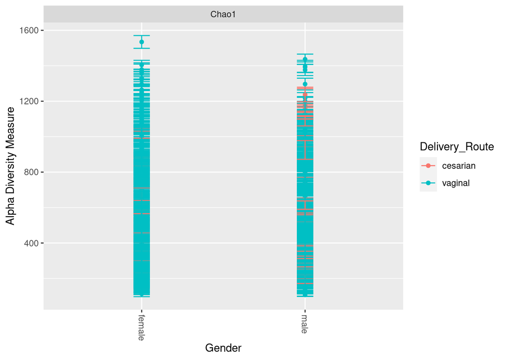

```r
#Alpha Diversity
plot_richness(physeq, x = "Gender", color = "Delivery_Route", measures = "Chao1")
```

#### Plot Chao1 richness estimator and Shannon diversity

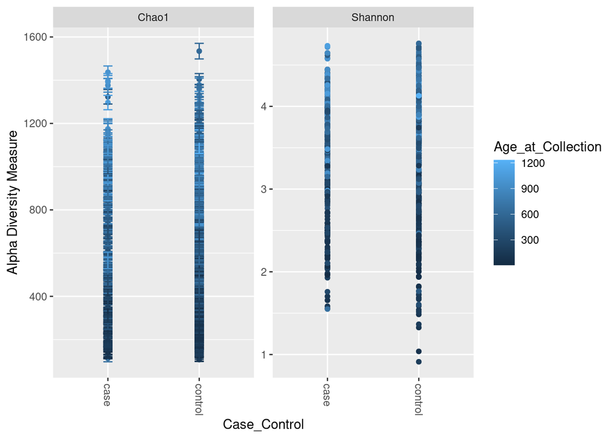

```r
plot_richness(physeq, measures=c("Chao1", "Shannon"), x="Case_Control", color = "Age_at_Collection")
```

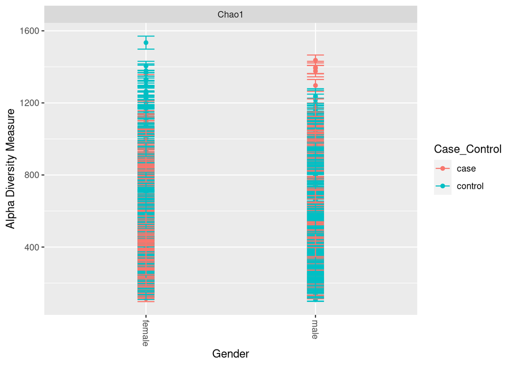

```r
plot_richness(physeq, x = "Gender", color = "Case_Control", measures = "Chao1")
```

### Ordination plots

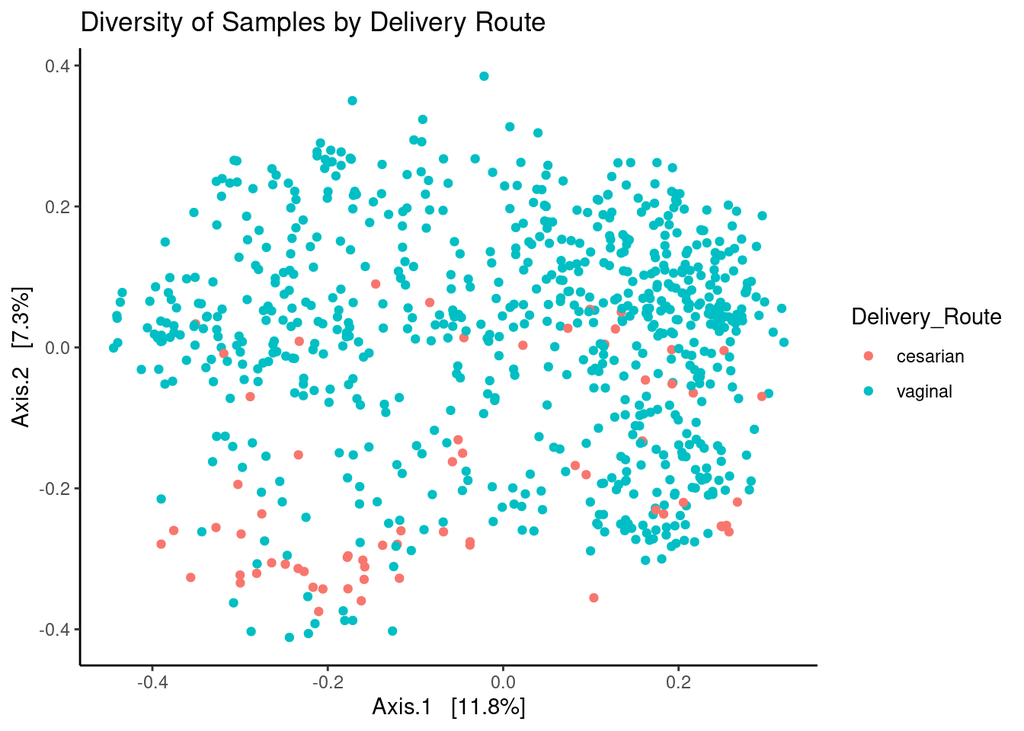

```r
#Ordination Plots
ordinate(physeq, "PCoA", "bray")%>% plot_ordination(physeq, .,color = "Delivery_Route", title = "Diversity of Samples by Delivery Route") + theme_classic()
```

## Differential abundance using DESeq2

Below is the summary of the phyloseq object i used , as well as the first few entries of different factors in the object.

```r
head(sample_data(physeq)$Case_Control, 10)
```

```
##  [1] control control control control control control control control control
## [10] control
## Levels: case control
```

```r
head(sample_data(physeq)$Delivery_Route, 10)
```

```
##  [1] vaginal vaginal vaginal vaginal vaginal vaginal vaginal vaginal vaginal
## [10] vaginal
## Levels: cesarian vaginal
```

```r
head(sample_data(physeq)$Gender, 10)
```

```
##  [1] female female male   female male   female female female male   female
## Levels: female male
```

## Converting the phloseq object to DESeq2

```r
deseq_object <- phyloseq_to_deseq2(physeq, ~ Case_Control)
```

```
##   it appears that the last variable in the design formula, 'Case_Control',
##   has a factor level, 'control', which is not the reference level. we recommend
##   to use factor(...,levels=...) or relevel() to set this as the reference level
##   before proceeding. for more information, please see the 'Note on factor levels'
##   in vignette('DESeq2').
```

```r
deseq_object
```

```
## class: DESeqDataSet
## dim: 2240 777
## metadata(1): version
## assays(1): counts
## rownames(2240): 4333897 190162 ... 187121 208972
## rowData names(0):
## colnames(777): G37016 G36918 ... G35981 G35973
## colData names(5): Subject_ID Case_Control Gender Delivery_Route
##   Age_at_Collection
```

#### Differential abundance using DESeq2

Converting the phloseq object to DESeq2 and then caling and viewing the results.

```r
OTU_matrix1 <-  OTU_mat+1
OTU1 <- otu_table(OTU_matrix1, taxa_are_rows = TRUE)
deseq_object <- phyloseq(OTU1, TAX, Samples)
TID_ds <- phyloseq_to_deseq2(deseq_object, ~ Case_Control)
```

```
##   it appears that the last variable in the design formula, 'Case_Control',
##   has a factor level, 'control', which is not the reference level. we recommend
##   to use factor(...,levels=...) or relevel() to set this as the reference level
##   before proceeding. for more information, please see the 'Note on factor levels'
##   in vignette('DESeq2').
```

Running deseq function

```r
TID_dds <- DESeq(TID_ds)
```

```
## -- note: fitType='parametric', but the dispersion trend was not well captured by the
##    function: y = a/x + b, and a local regression fit was automatically substituted.
##    specify fitType='local' or 'mean' to avoid this message next time.
```

```
## -- replacing outliers and refitting for 991 genes
## -- DESeq argument 'minReplicatesForReplace' = 7
## -- original counts are preserved in counts(dds)
```

Viewing results table

```r
TID_res <- results(TID_dds)
head(TID_res)
```

```
## log2 fold change (MLE): Case Control control vs case
## Wald test p-value: Case Control control vs case
## DataFrame with 6 rows and 6 columns
##                 baseMean     log2FoldChange             lfcSE
##                <numeric>          <numeric>         <numeric>
## 4333897 15.5174698749562 0.0779440821322282 0.154641298616505
## 190162  13.9656561828363 -0.441883737721236  0.13760861502383
## 134726  8.65693448372567   1.69368210625248 0.178847408190658
## 679245  11.1482521401337 -0.540014097912415 0.178828325710568
## 289734  1551.17877220295 -0.183347307572811 0.187915390302856
## 302049  106.474192550587 -0.603076290923956 0.161302525762877
##                       stat               pvalue                 padj
##                  <numeric>            <numeric>            <numeric>
## 4333897  0.504031476905286    0.614239257765115    0.678115296891995
## 190162   -3.21116332465605  0.00132198776526812   0.0031369201209752
## 134726    9.46998406846889  2.7988637936575e-21 4.44642191332823e-20
## 679245   -3.01973468558008  0.00252996201593033  0.00566145346222172
## 289734  -0.975690747188494     0.32921773886767     0.40408095071977
## 302049   -3.73879012787753 0.000184908010961279 0.000530337957174474
```

Summary of differential abundance

```r
#summary of results
summary(TID_res)
```

```
##
## out of 2240 with nonzero total read count
## adjusted p-value < 0.1
## LFC > 0 (up)       : 898, 40%
## LFC < 0 (down)     : 561, 25%
## outliers [1]       : 0, 0%
## low counts [2]     : 0, 0%
## (mean count < 1)
## [1] see 'cooksCutoff' argument of ?results
## [2] see 'independentFiltering' argument of ?results
```

```r
deseq.results <- as.data.frame(TID_res)
deseq.results %>%  arrange(log2FoldChange, padj)
```

```
##            baseMean log2FoldChange      lfcSE          stat        pvalue
## 357305    36.833238  -4.4554614229 0.20411659 -21.828022161 1.257449e-105
## 3039313   31.672260  -3.8895618382 0.20546229 -18.930782040  6.361100e-80
## 113069    27.079313  -3.7501651750 0.20246541 -18.522498142  1.359786e-76
## 2134134    6.506172  -3.5955198666 0.15759681 -22.814673785 3.278901e-115
## 840376    29.796294  -3.3580598413 0.20462011 -16.411191750  1.590525e-60
## 4401580  139.428182  -3.2092518663 0.19699027 -16.291423335  1.135554e-59
## 354574     6.171230  -3.1440032662 0.14227237 -22.098480890 3.268802e-108
## 1105984    4.104460  -2.9308902665 0.14526958 -20.175526887  1.606427e-90
## 4396292    7.202524  -2.8153213715 0.15935778 -17.666670743  7.573680e-70
## 4020502  198.255394  -2.5778122263 0.23979625 -10.750010723  5.925473e-27
## 4463108    3.222651  -2.5751114033 0.14039723 -18.341610896  3.852115e-75
## 193314     3.368792  -2.4096644198 0.14305485 -16.844339567  1.154507e-63
## 196382     3.433317  -2.4089446716 0.12997912 -18.533319985  1.112089e-76
## 4372003    3.816606  -2.3780605909 0.14582147 -16.308027506  8.654252e-60
```

[output cut: 4467 more lines]